# Klasyfikacja twarzy osób noszących okulary

- Show All Code
- Hide All Code
- View Source

Autor

Igor Nowiński

# Cel badania

Celem jest stworzenie jak najlepszej sieci neuronowej, przeznaczonej do klasyfikacji dwuklasowej.

# Opis zbioru danych

Zbiór danych pochodzi z [Kaggle](https://www.kaggle.com/datasets/jeffheaton/glasses-or-no-glasses/data). Został stworzony na potrzeby projektu naukowego wchodzącego w kurs o zastosowaniach sieci głębokich na Washington University w St. Louis. Zawiera on 93604 zdjęć twarzy osób noszących okulary lub nie. Zostały one stworzone przez generatywną sieć przeciwników (ang. Generative Adversarial Network).

### Przykładowe zdjęcia

**Z okularami**

**Pokaż kod**

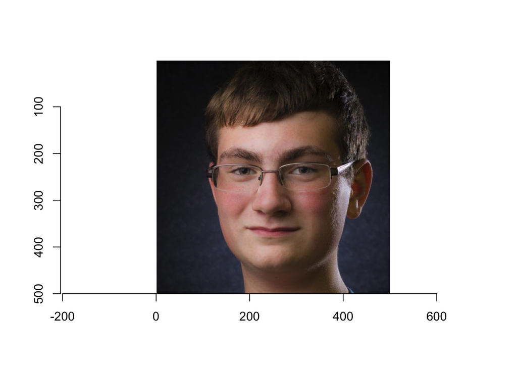

Rysunek 1: Przykładowe zdjęcie osoby noszącej okulary

```r
plot(with_glasses_example)
```

**Bez okularów**

**Pokaż kod**

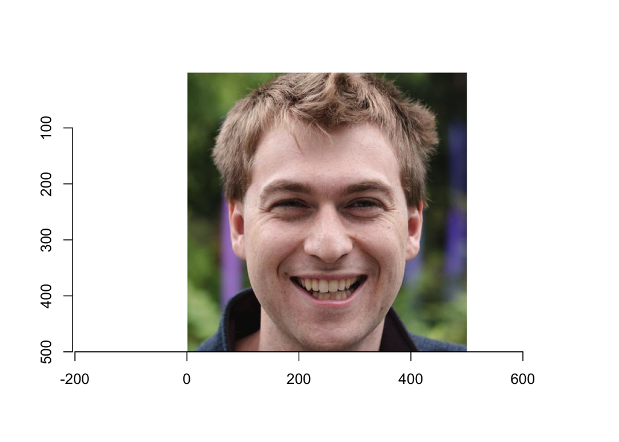

Rysunek 2: Przykładowe zdjęcie osoby nie noszącej okularów

```r
plot(without_glasses_example)
```

## Podział zbioru na część treningową, walidacyjną i testową

Podzieliłem zbiór na odpowiednie części, gdzie rozkład klas widać w tabelkach poniżej. Do dalszej analizy przyjmuję oznaczenia klas:

- 0 - osoba z okularami
- 1 - osoba bez okularów

**Pokaż kod**

```r
tabela_podzialu <- as.data.frame(tabela_podzialu)
rownames(tabela_podzialu) <- c("Treningowy", "Walidacyjny", "Testowy")
tabela_podzialu %>% gt(rownames_to_stub = T)
```

Tabela 1: Liczba zdjęć danej klasy w zbiorze treningowym, walidacyjnym i testowym

|  | 0 | 1 |
| --- | --- | --- |
| Treningowy | 27297 | 47586 |
| Walidacyjny | 5459 | 9517 |
| Testowy | 1365 | 2380 |

Zbiór nie jest zbalansowany, znacznie więcej jest zdjęć osób bez okularów.

# Budowa sieci neuronowych

Jako funkcję aktywacji wybrałem *relu*, a do ostatniej warstwy - *sigmoid*. Modele uczone były przez 30 epok z 50 krokami w każdej z nich. Walidacja odbyła się na 50 krokach.

Funkcją straty jest binarna entropia krzyżowa, optymalizatorem jest `adam` i skupiłem się na *accuracy*.

**1**

Pierwszą sieć zbudowałem z założeniem, aby nie była zbytnio skomplikowana. Składa się z 2 warstw neuronów.

**Pokaż kod**

```r
model1 <- keras_model_sequential() %>%
  layer_dense(units = 16, activation = 'relu',
              input_shape = c(150, 150, 3)) %>%
  layer_flatten() %>%
  layer_dense(units = 1, activation = 'sigmoid')

model1 %>% compile(
    loss = 'binary_crossentropy',
    optimizer = "adam",
    metrics = c('accuracy'))
```

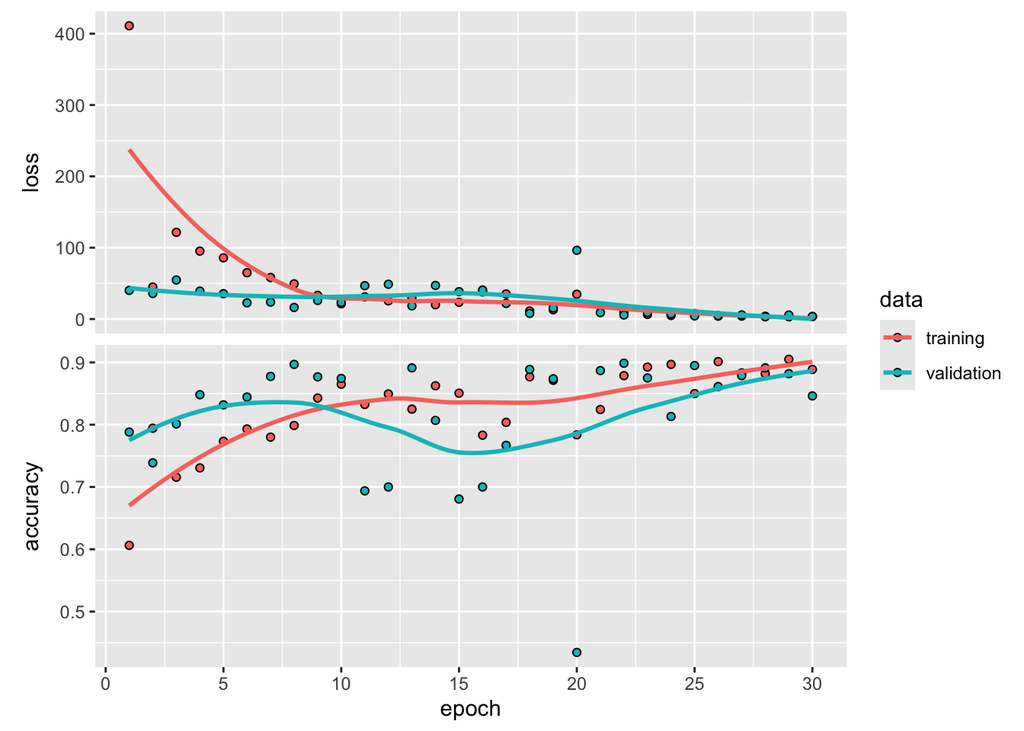

Rysunek 3: Uczenie modelu 1

Na wykresie możemy zauważyć, że wartości wahały się pomiędzy 10 a 20 epoką.

**2**

Dodałem kilka dodatkowych warstw gęstych neuronów oraz warstwy dropout, aby zapobiec przeuczeniu.

**Pokaż kod**

```r
model2 <- keras_model_sequential() %>%
  layer_dense(units = 16, activation = 'relu',
              input_shape = c(150, 150, 3)) %>%
  layer_dense(units = 16, activation = 'relu') %>%
  layer_dropout(0.3) %>%
  layer_dense(units = 16, activation = 'relu') %>%
  layer_dropout(0.3) %>%
  layer_dense(units = 16, activation = 'relu') %>%
  layer_dropout(0.3) %>%
  layer_flatten() %>%
  layer_dense(units = 1, activation = 'sigmoid')

model2 %>% compile(
    loss = 'binary_crossentropy',
    optimizer = "adam",
    metrics = c('accuracy'))
```

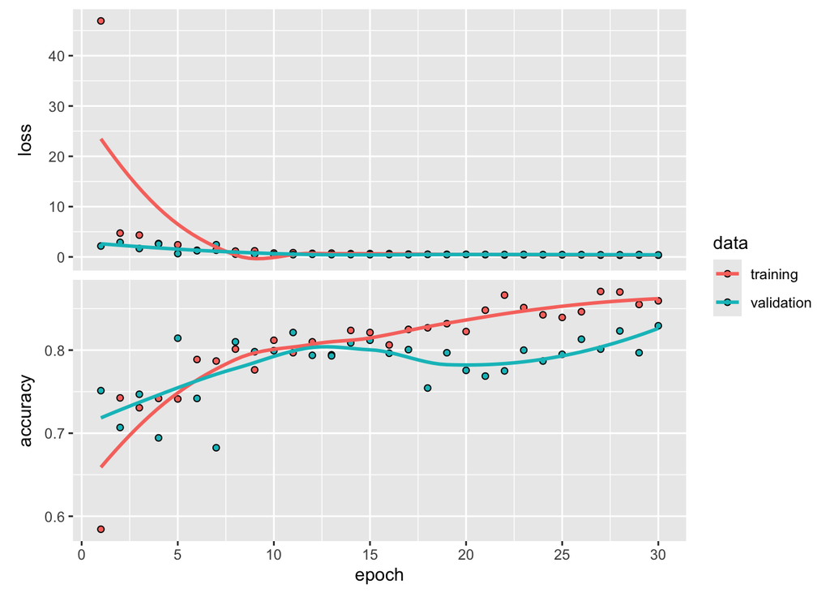

Rysunek 4: Uczenie modelu 2

Ostatecznie model jest przeuczony, czas na zmianę strategii.

**3**

Dalej chciałem spróbować zastosować warstwy konwolucyjne.

**Pokaż kod**

```r
model3 <- keras_model_sequential() %>%
  layer_dense(units = 16, activation = 'relu',
              input_shape = c(150, 150, 3)) %>%
  layer_dropout(0.1) %>%
  layer_conv_2d(filters = 32, kernel_size = 3,
                activation = 'relu') %>%
  layer_dropout(0.1) %>%
  layer_dense(units = 16, activation = 'relu') %>%
  layer_flatten() %>%
  layer_dense(units = 1, activation = 'sigmoid')

model3 %>% compile(
    loss = 'binary_crossentropy',
    optimizer = optimizer_adam(lr = 1e-4),
    metrics = c('accuracy')
)
```

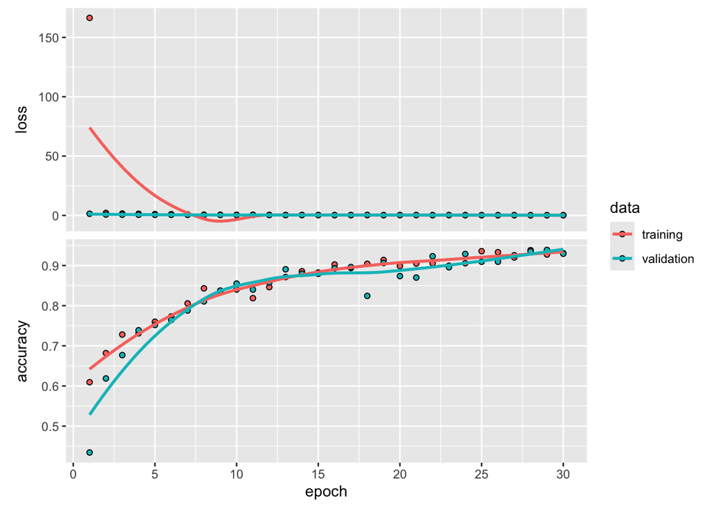

Rysunek 5: Uczenie modelu 3

Wyniki są o wiele lepsze od poprzednich modeli.

**Ostatni model**

**Pokaż kod**

```r
final_model <- keras_model_sequential() %>%
layer_conv_2d(filters = 32, kernel_size = 3,
              activation = 'relu',
              input_shape = c(150, 150, 3)) %>%
layer_max_pooling_2d(pool_size = 2) %>%
layer_conv_2d(filters = 64, kernel_size = 3, activation = 'relu') %>%
layer_max_pooling_2d(pool_size = 2) %>%
layer_dropout(0.3) %>%
layer_conv_2d(filters = 128, kernel_size=3, activation = 'relu') %>%
layer_dense(units = 128, activation = 'relu') %>%
layer_flatten() %>%
layer_dense(units = 1, activation = 'sigmoid')

final_model %>% compile(
    loss = 'binary_crossentropy',
    optimizer = optimizer_adam(lr = 1e-4),
    metrics = c('accuracy')
)
```

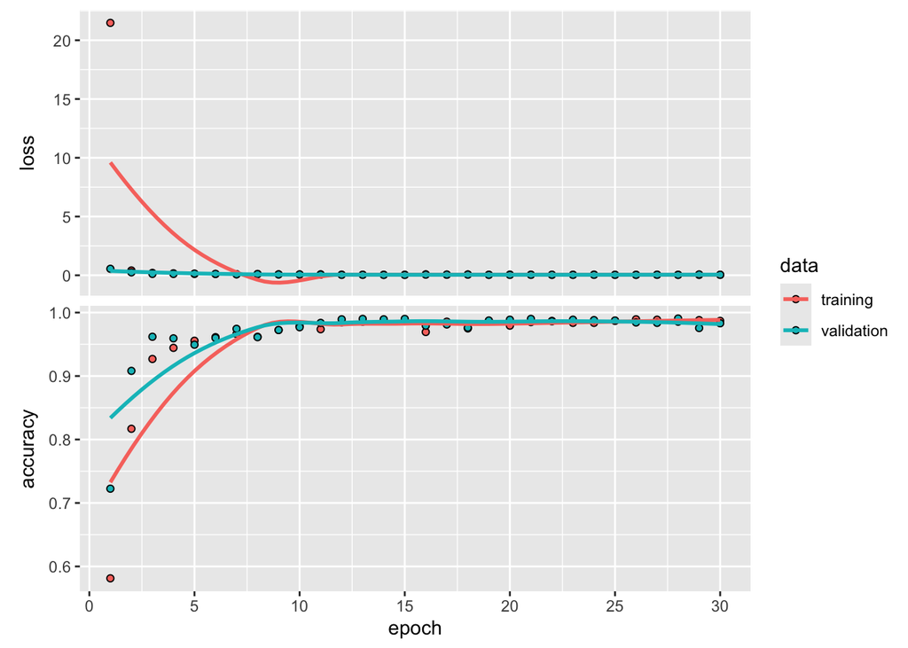

Rysunek 6: Uczenie ostatniego modelu

Możemy zauważyć, że tutaj nie występuje przeuczenie oraz wyniki są zadowalające.

# Podsumowanie i wnioski

Tabela 2: Wartości funkcji straty oraz accuracy dla poszczególnych modeli

|  | loss | accuracy |
| --- | --- | --- |
| model 1 | 3.68 | 0.85 |
| model 2 | 0.42 | 0.83 |
| model 3 | 0.21 | 0.94 |
| model 4 | 0.05 | 0.99 |

W Tabela 2 powyżej zawarłem wyniki jakie uzyskałem po nauczeniu modeli oraz sprawdzeniu ich na zbiorze testowym. Można zauważyć, że pierwszy z nich ma bardzo dużą, w porównaniu do innych, wartość funkcji straty. Accuracy na poziomie 0.85 nie jest wynikiem złym, natomiast można je poprawić.

Drugi model znacząco obniżył wartość funkcji straty, kosztem małego spadku accuracy.

Zastosowanie warstw konwolucyjnych poprawiło możliwości, dochodząc do accuracy na poziomie 0.99. Wartość funkcji straty jest minimalna, porównując ją z pierwszym modelem.